## **Gould’s mouse**

### Blamed on cats

[figure not shown]

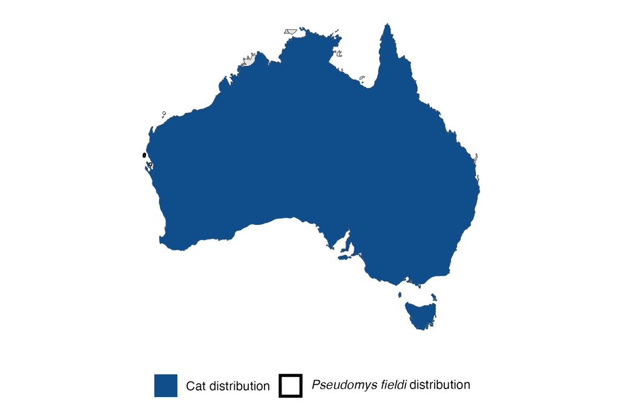

IUCN status: **Vulnerable**

EPBC Predator Threat Rating: **Not assessed**

IUCN claim: *“Predation by feral Domestic Cats (Felis catus), Red Foxes (Vulpes vulpes) and Black Rats (Rattus rattus) could have severe to catastrophic effects if they establish on island. Feral Cats and Red Foxes have caused the extinction of medium-sized mammals on arid Australian islands”*

### Studies in support

Gould’s mice were last confirmed in Alice Springs 15-25 years after cats arrived (Wallach and Lundgren 2025).

### Studies not in support

Gould’s mice were last confirmed in the Western Division of NSW and in southwest Australia 23 and 50 years before, to 27 and 19 years after, cats arrived, respectively (Wallach and Lundgren 2025).

### Is the threat claim evidence-based?

No studies were found linking cats to Gould’s mice. In two regions it cannot be verrified that extirpation occurred after cat arrival.

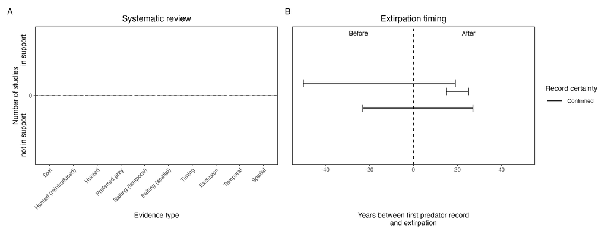

**Evidence linking *Pseudomys fieldi* to cats.** Systematic review of evidence for an association between *Pseudomys fieldi* and cats. Positive studies are in support of the hypothesis that *cats* contribute to the decline of Pseudomys fieldi, negative studies are not in support. Predation studies include studies documenting hunting or scavenging; baiting studies are associations between poison baiting and threatened mammal abundance where information on predator abundance is not provided; population studies are associations between threatened mammal and predator abundance. Gold borders indicate studies that meet qualities of scientific rigour. See methods section in Wallach and Lundgren 2025 for details on evidence categories.

### References

IUCN Red List. https://www.iucnredlist.org/ Accessed June 2023

Wallach A.D., Lundgren E.J. (2025) Review of evidence that foxes and cats cause extinctions of Australia’s endemic mammals. BioScience. DOI: 10.1093/biosci/biaf046